```python
from IPython.display import Image, HTML
import requests

import ichabod

SVG_TIGER_URL = "http://upload.wikimedia.org/wikipedia/commons/f/fd/Ghostscript_Tiger.svg"

TIGER_HTML = '<img src="{}" width="400" height="200" />'.format(SVG_TIGER_URL)

TIGER_OUTPUT = '/tmp/tiger.png'
```

# Creating an Ichabod client

An ichabod client can be constructed with no arguments. Below we construct it with a port and a timeout, since ours is not running on the default port, and we it timeout quickly if necessary.

```python
client = ichabod.IchabodClient(port=9191, timeout=5)
```

## Hello, world!

The client provides three rasterization methods: `rasterize`, which accepts an `html` or `url` argument, as well as `rasterize_html` and `rasterize_url`, which only accept each arugment respectively. The only two required arguments are `html` or `url` and `width`, which gives our browser a width.

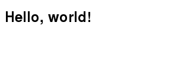

```python
result = client.rasterize(html='<h2>Hello, world!</h2>', width=300)

Image(filename=result['path'])
```

## Performance

Ichabod is built to render and return a repsonse quickly. Below we can use the IPython `%%timeit` magic to see just how fast our example renders. In this case, it takes just under 7 ms per run.

```python
%%timeit
client.rasterize(html='<h1>Hello, world!</h1>', width=300)
```

```
100 loops, best of 3: 6.9 ms per loop
```

Here's a more complex example: the classic SVG tiger.

```python
%%timeit
client.rasterize(
    output=TIGER_OUTPUT,
    html=TIGER_HTML,
    width=400)
```

```
10 loops, best of 3: 23.5 ms per loop
```

[figure not shown]

```python
Image(filename='/tmp/tiger.png')
```

## Comparable technologies

Since we're using the classic SVG tiger, we can compare our timing metrics to the example in the [phantomjs](http://phantomjs.com) documentation.

PLEASE NOTE: this is not an apples-to-apples comparison, since it includes the time it takes to start the phantomjs runtime. In our testing, ichabod is still roughly an order of magnitude faster at rendering, but perhaps not 20x faster, if we profile just the rendering.

```python
%%timeit -n 10
!phantomjs /usr/share/phantomjs/examples/rasterize.js http://upload.wikimedia.org/wikipedia/commons/f/fd/Ghostscript_Tiger.svg /tmp/tiger.png
```

```
10 loops, best of 3: 590 ms per loop
```

## Rendering webpages by URL

We can also pass the `url` keyword argument to render a remote resource.

```python
result = client.rasterize_url(url='http://example.com', width=1000, height=500)
```

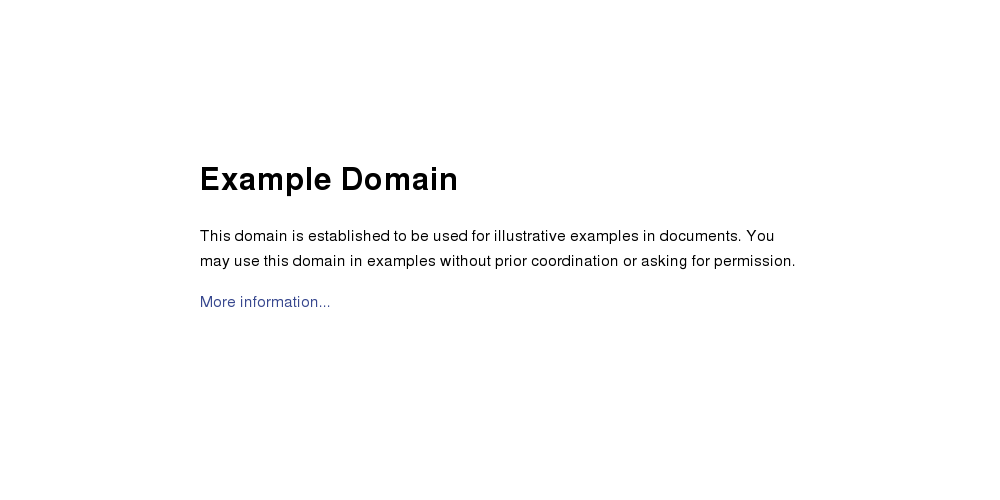

```python
Image(filename=result['path'])
```

## Evaluating JS

We can pass JavaScript code with the `js` parameter which is evaluated in the page context and returned in the resulting JSON in the `result` key. Given that we're communicating with a relatively fast page, this should return quickly as well.

```python
print client.evaluate(
    js='(function() { return JSON.stringify(document.characterSet); })()',
    url='http://example.com')['result']
```

```
UTF-8
```

```python
%%timeit
client.evaluate(
    js='(function() { return JSON.stringify(document.characterSet); })()',
    url='http://example.com')
```

```
100 loops, best of 3: 9.9 ms per loop
```

## Animations and the ichabod JS API

Ichabod exposes an API which scripts in the `js` parameter can use to control when the page is rasterized, and to create complex animations.

```python
ANIMATION_HTML = """
<html>
<head>
    <style>
        body {background: transparent;}
        #matrix {color: green; width: 390; overflow: auto; font-family: monospace}
    </style>
</head>
<body>
    <div id="matrix">LOADING ...</div>
</body>
</html>
"""

ANIMATION_JS = """
(function() {
    ichabod.setTransparent(1);
    ichabod.setLooping(1);
    var matrix = document.getElementById('matrix');
    for (var i = 1; i < 100; i++) {
        var codez = [];
        for (var j = 1; j < 666; j++) {
            codez.push(Math.random() < 0.5 ? 0 : 1);
        }
        matrix.innerText = codez.join(' ');
        ichabod.snapshotPage(10);
    }
    ichabod.saveToOutput();
})()
"""

# HACK! IPython notebook doesn't want to show a .gif file.
ANIMATION_OUTPUT = '/tmp/example-anim.png'

animation_result = client.evaluate(
    format='gif',
    html=ANIMATION_HTML,
    output=ANIMATION_OUTPUT,
    js=ANIMATION_JS,
    width=400,
    height=400)
```

```python
Image(filename=ANIMATION_OUTPUT)
```

[output not shown]